# 440 Reproducibility and Statistics Assignment Example

First we need to load the data.

```r
pols<-read.csv("politics.csv")
```

Let’s take a look at the data.

```r
str(pols)
```

```
## 'data.frame':    132 obs. of  7 variables:
##  $ subject      : int  1 2 3 4 5 6 7 8 9 10 ...
##  $ party        : Factor w/ 3 levels "democrat","independent",..: 3 3 2 2 2 3 3 2 3 2 ...
##  $ testtime     : Factor w/ 2 levels "post","pre": 2 2 2 2 2 2 2 2 2 2 ...
##  $ optimismscore: int  52 51 69 51 61 31 57 48 42 64 ...
##  $ minwage      : Factor w/ 2 levels "no","yes": 1 1 2 1 2 1 1 1 1 1 ...
##  $ sex          : Factor w/ 2 levels "female","male": 2 2 1 2 2 2 2 2 2 2 ...
##  $ income       : num  37.3 42.3 73 33.8 57.3 ...
```

Subject should be a factor variable. Additionally, I prefer it when “pre” precedes “post”. So I’m going to refactor those variables.

```r
pols$subject<-factor(pols$subject)
pols$testtime<-factor(pols$testtime, levels=c("pre", "post"))
```

```r
summary(pols$income)
```

```
##    Min. 1st Qu.  Median    Mean 3rd Qu.    Max.
##   5.672  27.590  41.220  43.040  56.010 114.800
```

Let’s see how incomes are distributed. I noticed that there each income is represented twice. So to avoid over counting incomes, I’ll only use the data from the posttests to create a histogram.

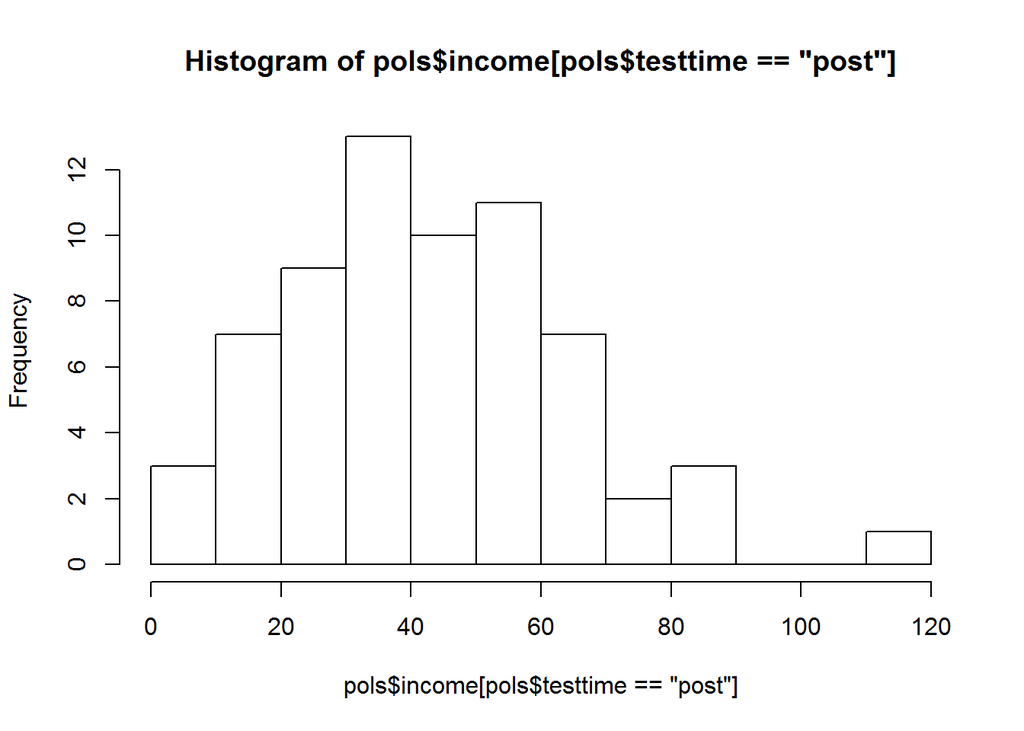

```r
hist(pols$income[pols$testtime=="post"])
```

```r
tab<-table(pols$party[pols$testtime=="pre"],pols$minwage[pols$testtime=="pre"])
```

```r
chisq.test(pols$party[pols$testtime=="pre"],pols$minwage[pols$testtime=="pre"])
```

```
##
##  Pearson's Chi-squared test
##
## data:  pols$party[pols$testtime == "pre"] and pols$minwage[pols$testtime == "pre"]
## X-squared = 6.4037, df = 2, p-value = 0.04069
```

Political affiliation is not independent of support for minimum wage increases, Chi-Square(2) = 6.4, p = .04.

To see whether or not males and females have different optimism scores before watching *AFHV* we can run an independent t-test.

```r
t.test(pols$optimism[pols$sex=="male" & pols$testtime=="pre"],pols$optimism[pols$sex=="female" & pols$testtime=="pre"])
```

```
##
##  Welch Two Sample t-test
##
## data:  pols$optimism[pols$sex == "male" & pols$testtime == "pre"] and pols$optimism[pols$sex == "female" & pols$testtime == "pre"]
## t = -0.37442, df = 62.936, p-value = 0.7094
## alternative hypothesis: true difference in means is not equal to 0
## 95 percent confidence interval:
##  -10.946279   7.491733
## sample estimates:
## mean of x mean of y
##  54.12121  55.84848
```

Males and females do not differ in optimism before watching *AFHV*, t(62.9) = -.37, p = .71.

To create the figure, I need to include the dplyr library. Then I’ll use it to summarize the politics data set and find the means and standard errors for the different conditions. Then I’ll need the ggplot2 library to create a nice plot that’s easy to work with. I’ll do the same thing for any other graphs I create unless I specify otherwise.

```r
library("dplyr")
```

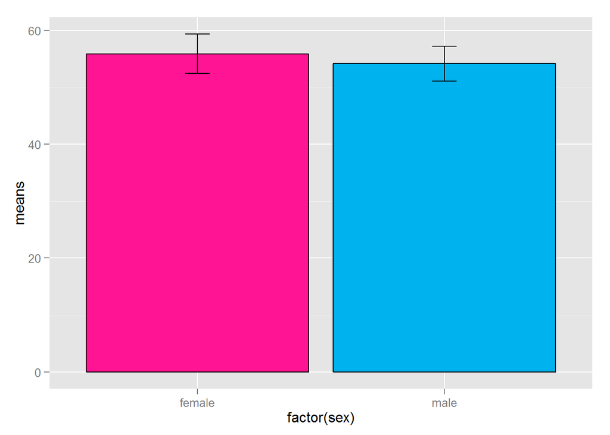

```r
temp<-pols[pols$testtime=="pre",]%>%group_by(sex)%>%summarize(means=mean(optimismscore),
              sems=sd(optimismscore)/sqrt(length(optimismscore)))
library("ggplot2")
f<-ggplot(temp,aes(x=factor(sex),y=means))+
    geom_bar(stat="identity", color="black",fill=c("deeppink","deepskyblue2"))+
    geom_errorbar(aes(ymax=means+sems, ymin=means-sems), width=.1)
f
```

That’s a bare minimum graph that might be ok for others, but not for me.

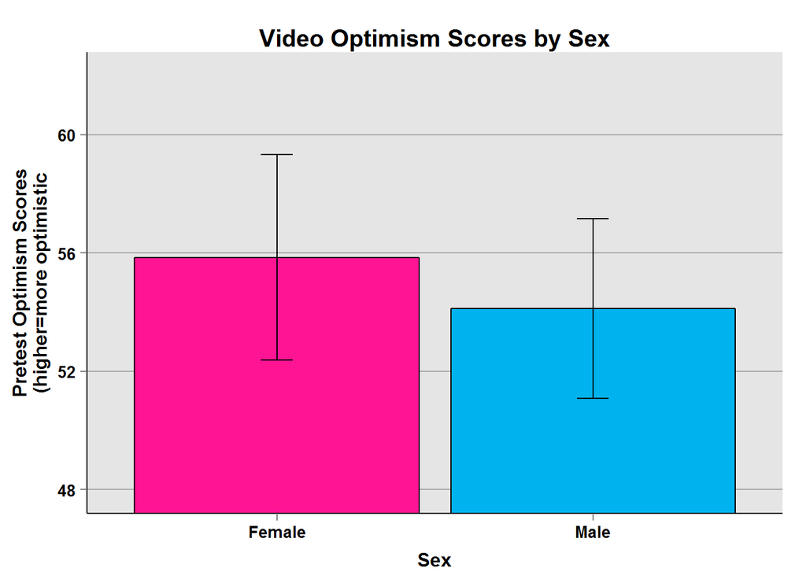

```r
f<-f+ggtitle("Video Optimism Scores by Sex")+
    labs(x="Sex", y="Pretest Optimism Scores\n(higher=more optimistic")+
    scale_x_discrete(breaks=c("female","male"),labels=c("Female","Male"))+
    theme(plot.title=element_text(size=15,face="bold",vjust=.5))+
    theme(axis.title.x=element_text(size=12,face="bold",vjust=-.25))+
    theme(axis.title.y=element_text(size=12,face="bold",vjust=1))+
    theme(axis.text.x=element_text(size=10,face="bold",color="black"))+
    theme(axis.text.y=element_text(size=10,face="bold",color="black"))+
    coord_cartesian(ylim=c(min(temp$means)-2*max(temp$sems),max(temp$means)+2*max(temp$sems)))+
    theme(panel.border=element_blank(), axis.line=element_line())+
    theme(panel.grid.major.x=element_blank())+
    theme(panel.grid.major.y=element_line(color="darkgrey"))+
    theme(panel.grid.minor.y=element_blank())
f
```

That’s much better.

Let’s see if party affiliation and sex predict incomes independently or in an interaction using a 2-way between-subjects ANOVA.

```r
 summary(aov(income~party*sex,data=pols[pols$testtime=="pre",]))
```

```
##             Df Sum Sq Mean Sq F value Pr(>F)
## party        2   3973  1986.7   4.544 0.0145 *
## sex          1   1563  1563.0   3.575 0.0635 .
## party:sex    2     63    31.3   0.072 0.9311
## Residuals   60  26234   437.2
## ---
## Signif. codes:  0 '***' 0.001 '**' 0.01 '*' 0.05 '.' 0.1 ' ' 1
```

Income is related to party affiliation, F(2, 60) = 4.54, p = .015, but not to sex, F(1, 60) = 3.58, p = .064, or an interaction between affiliation and sex, F(2, 60) = .07, p = .93.

To create the plot and manually adjust the fill, I need to use hexadecimal color codes. To convert the named colors I like to hexadecimal, I need to use the gplots library.

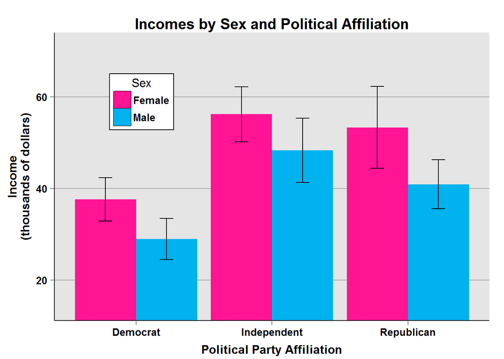

```r
temp<-pols[pols$testtime=="pre",]%>%group_by(party,sex)%>%
    summarize(means=mean(income),sems=sd(income)/sqrt(length(income)))
library("gplots")
col1=col2hex("deeppink")
col2=col2hex("deepskyblue2")
f<-ggplot(temp, aes(x=party, y=means, fill=sex))+
    geom_bar(stat="identity",position=position_dodge())+
    scale_fill_manual(values=c(col1,col2),name="Sex",breaks=c("female","male"),labels=c("Female", "Male"))+
    theme(legend.key=element_rect(color="black"))+
    geom_errorbar(aes(ymax=means+sems, ymin=means-sems),width=.2,position=position_dodge(.9))+
    ggtitle("Incomes by Sex and Political Affiliation")+
    labs(x="Political Party Affiliation",y="Income\n(thousands of dollars)")+
    scale_x_discrete(breaks=c("democrat","independent","republican"),labels=c("Democrat","Independent","Republican"))+
    theme(plot.title=element_text(size=15,face="bold",vjust=.5))+
    theme(axis.title.x=element_text(size=12,face="bold",vjust=-.25))+
    theme(axis.title.y=element_text(size=12,face="bold",vjust=1))+
    theme(axis.text.x=element_text(size=10,face="bold",color="black"))+
    theme(axis.text.y=element_text(size=10,face="bold",color="black"))+
    coord_cartesian(ylim=c(min(temp$means)-2*max(temp$sems),max(temp$means)+2*max(temp$sems)))+
    theme(panel.border=element_blank(),axis.line=element_line())+
    theme(panel.grid.major.x=element_blank())+
    theme(panel.grid.major.y=element_line(color="darkgrey"))+
    theme(panel.grid.minor.y=element_blank())+
    theme(legend.position=c(.2,.76))+
    theme(legend.background=element_blank())+
    theme(legend.background=element_rect(color="black"))+
    theme(legend.title=element_blank())+
    theme(legend.title=element_text(size=12))+
    theme(legend.title.align=.5)+
    theme(legend.text=element_text(size=10,face="bold"))
f
```

Although, we shouldn’t make a line graph for these data, my moronic instructor thinks I need the practice. Oh, shoot. I hope he doesn’t dock my grade for that. Whatevs. lol! :)

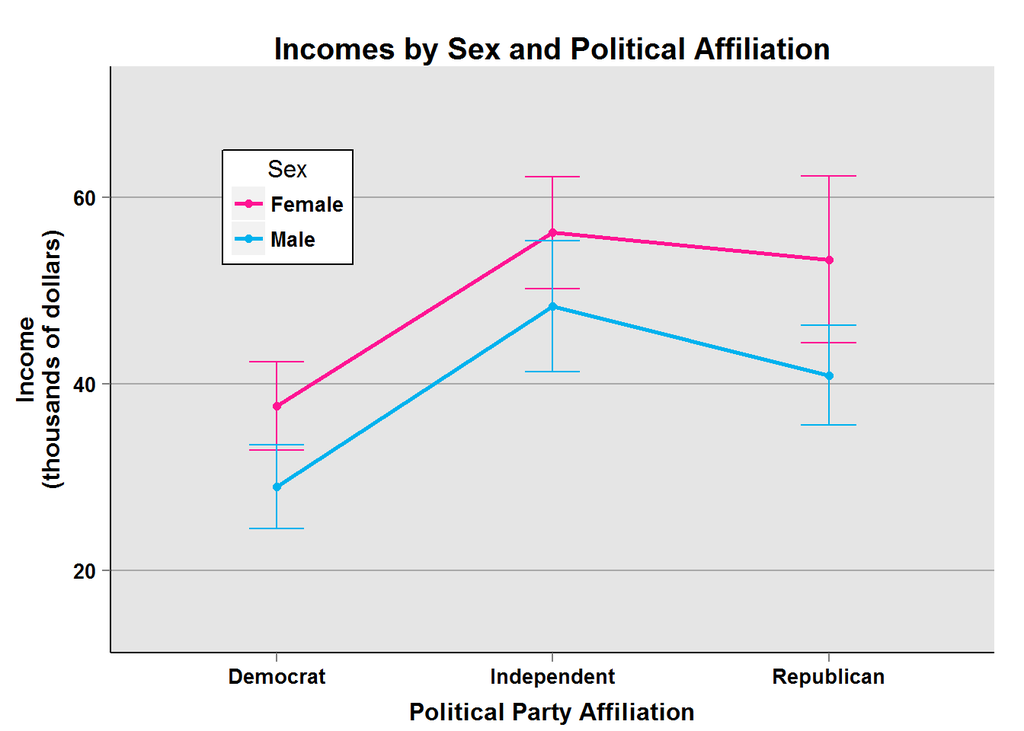

```r
f<-ggplot(temp, aes(x=party, y=means, group=sex, color=sex))+
    geom_line(size=1)+
    geom_point(size=2)+
    scale_color_manual(values=c(col1,col2),name="Sex",breaks=c("female","male"),labels=c("Female", "Male"))+
    geom_errorbar(aes(ymax=means+sems, ymin=means-sems),width=.2)+
    ggtitle("Incomes by Sex and Political Affiliation")+
    labs(x="Political Party Affiliation",y="Income\n(thousands of dollars)")+
    scale_x_discrete(breaks=c("democrat","independent","republican"),labels=c("Democrat","Independent","Republican"))+
    theme(plot.title=element_text(size=15,face="bold",vjust=.5))+
    theme(axis.title.x=element_text(size=12,face="bold",vjust=-.25))+
    theme(axis.title.y=element_text(size=12,face="bold",vjust=1))+
    theme(axis.text.x=element_text(size=10,face="bold",color="black"))+
    theme(axis.text.y=element_text(size=10,face="bold",color="black"))+
    coord_cartesian(ylim=c(min(temp$means)-2*max(temp$sems),max(temp$means)+2*max(temp$sems)))+
    theme(panel.border=element_blank(),axis.line=element_line())+
    theme(panel.grid.major.x=element_blank())+
    theme(panel.grid.major.y=element_line(color="darkgrey"))+
    theme(panel.grid.minor.y=element_blank())+
    theme(legend.position=c(.2,.76))+
    theme(legend.background=element_blank())+
    theme(legend.background=element_rect(color="black"))+
    theme(legend.title=element_blank())+
    theme(legend.title=element_text(size=12))+
    theme(legend.title.align=.5)+
    theme(legend.text=element_text(size=10,face="bold"))
f
```

To see if optimism scores before and after watching *AFHV* vary depending on party affiliation, I’m going to run a 2-way mixed ANOVA. I’m using a mixed ANOVA because the same people indicated their optimism before and after the videos (i.e. a within-subjects factor) and because different people are affiliated with different political parties (i.e. a between-subjects factor).

```r
summary(aov(optimismscore~testtime*party+Error(subject/testtime),data=pols))
```

```
##
## Error: subject
##           Df Sum Sq Mean Sq F value   Pr(>F)
## party      2  21950   10975   32.56 1.95e-10 ***
## Residuals 63  21235     337
## ---
## Signif. codes:  0 '***' 0.001 '**' 0.01 '*' 0.05 '.' 0.1 ' ' 1
##
## Error: subject:testtime
##                Df Sum Sq Mean Sq F value   Pr(>F)
## testtime        1  770.9   770.9  42.526 1.35e-08 ***
## testtime:party  2   53.5    26.8   1.476    0.236
## Residuals      63 1142.1    18.1
## ---
## Signif. codes:  0 '***' 0.001 '**' 0.01 '*' 0.05 '.' 0.1 ' ' 1
```

Although optimism scores were related to political affiliation, F(2, 63) = 32.56, p < .001, and affected by watching videos, F(1, 63) = 42.53, p < .001, there was no interaction between taking the test before or after watching videos and their party affiliation, F(2, 63) = 1.48, p = .24.

I’m going to perform Multiple Regression to predict pretest optimism scores from income and sex.

```r
summary(lm(optimismscore~income+sex,data=pols[pols$testtime=="pre",]))
```

```
##
## Call:
## lm(formula = optimismscore ~ income + sex, data = pols[pols$testtime ==
##     "pre", ])
##
## Residuals:
##     Min      1Q  Median      3Q     Max
## -39.895 -14.114   0.712  12.807  37.844
##
## Coefficients:
##             Estimate Std. Error t value Pr(>|t|)
## (Intercept) 60.21456    6.03250   9.982 1.35e-14 ***
## income      -0.09236    0.10725  -0.861    0.392
## sexmale     -2.50914    4.71091  -0.533    0.596
## ---
## Signif. codes:  0 '***' 0.001 '**' 0.01 '*' 0.05 '.' 0.1 ' ' 1
##
## Residual standard error: 18.78 on 63 degrees of freedom
## Multiple R-squared:  0.01379,    Adjusted R-squared:  -0.01751
## F-statistic: 0.4406 on 2 and 63 DF,  p-value: 0.6456
```

The linear model predicting pretest optimism scores from income and sex doesn’t explain any variance, R^2 = .014, F(2, 63) = .44, p = .65. Despite this lack of significance, I’m creating a scatter plot because my wonderful instructor thinks that practice makes perfect.

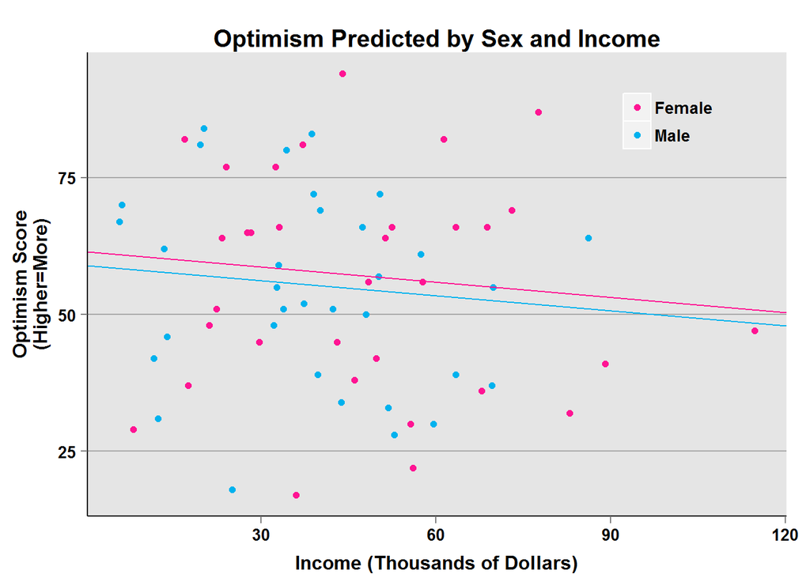

```r
f<-ggplot(pols[pols$testtime=="pre",],aes(x=income,y=optimismscore,color=sex))+
    geom_point(size=2)+
    geom_abline(intercept=60.2+2.51/2, slope=-.092,color=col1)+
    geom_abline(intercept=60.2-2.51/2, slope=-.092,color=col2)+
    scale_color_manual(values=c(col1,col2),breaks=c("female","male"),labels=c("Female","Male"))+
    ggtitle("Optimism Predicted by Sex and Income")+
    labs(x="Income (Thousands of Dollars)",y="Optimism Score\n(Higher=More)")+
    theme(plot.title=element_text(size=15,face="bold", vjust=.5))+
    theme(axis.title.x=element_text(size=12,face="bold", vjust=-.25))+
    theme(axis.title.y=element_text(size=12,face="bold", vjust=1))+
    theme(axis.text.x=element_text(size=10,face="bold",color="black"))+
    theme(axis.text.y=element_text(size=10,face="bold",color="black"))+
    theme(panel.border=element_blank(), axis.line=element_line())+
    theme(panel.grid.major.x=element_blank())+
    theme(panel.grid.minor.x=element_blank())+
    theme(panel.grid.major.y=element_line(color="darkgrey"))+
    theme(panel.grid.minor.y=element_blank())+
    theme(legend.position=c(.83,.86))+
    theme(legend.background=element_blank())+
    theme(legend.title=element_blank())+
    theme(legend.text=element_text(size=10,face="bold"))
f
```

*Fin*